# Coursework Report

*N* removed NAs: 2

*N* removed typo: 1

*N* removed <18: 28

*N* total clean: 119

| Group | *N* | *M*<sub>age</sub> | *M*<sub>rating</sub> |
| --- | --- | --- | --- |
| Control | 61 | 20.98 | 7.42 |
| Experim | 58 | 20.67 | 6.41 |

**Main analysis results**

*t*(117) = 7.34, *p* < .001

[interactive chart not shown]

[figure not shown]

[interactive chart not shown]

# Coursework Report

Analysing Data, Spring 2020

# Methods

## Participants

The participants for this study replication originally consisted of 150 individuals, with 79 in the control condition and 71 in the experimental condition. The total number of participants removed was 31, 2 were removed for being not applicable (NA) while another 29 were removed due to being under 18 and therefore of an unethical age to participate, this removal included an invalid age submission of “2t” that was recoded to age “0”. The final number of participants whose data was included in the results was then 119. The mean age of this final participant group was calculated to be 20.83, the standard deviation was calculated to be 1.93 and finally the range of participant ages was 8 years. The breakdown of participant ages by condition can be seen below in Figure 1.

*Figure 1.* Descriptive statistics of age by condition

| Condition | *N* | *Mean Age* | *SD Age* | *Min Age* | *Max Age* |
| --- | --- | --- | --- | --- | --- |
| White Control | 61 | 20.98 | 1.95 | 18 | 26 |
| Red Experimental | 58 | 20.67 | 1.91 | 18 | 24 |

## Design

The conceptual hypothesis for this study was “does colour influence attractiveness?”. This study had two operationalised variables which were the independent categorical variable and the continuous variable. The independent categorical variable for this study was the colour of the frames in which the image of a male was presented to the participants, which had two levels of either red or white. The red condition was the experimental and the white condition was the control, this is therefore the predictor as it was a manipulated factor. The continuous variable was attractiveness in the form of ratings on a 9-point scale, which were direct contributions to the final perceived attractiveness rating for each condition and was therefore the manipulated outcome of this study. The rated questions were “How attractive do you think this person is?”, “How pleasant is this person to look at?” and “If I were to meet the person in this picture face to face, I would think he is attractive.”. The scales ranged from 1 (not attractive) to 9 (extremely attractive), so a higher score indicated increased attractiveness perception from the participant. The operational hypothesis investigated in this study is whether viewing a different colour frame around an image of a moderately attractive man influences the mean ratings of his attractiveness. The ratings will be averaged to create a composite score for the conditions in order to come to a conclusion in a more holistic manner. A t-test will be used to analyse composite sores of all three rating variables by colour group, with red as the experimental and white as the control condition.

# Results

From the plot created we can see that the general pattern of results highlights that the control white condition had higher mean attractiveness ratings with a lower standard deviation value compared to the experimental red condition. From Figure 2 we can also see that the minimum and maximum results are both higher numbers for the control condition. From this basic overview it can already be advised that the background colour had an influence on the participants attractiveness perception and consequently their ratings. The fact that there is a difference also suggests that the results did not happen due to chance.

*Figure 2.* Descriptive statistics of mean attractiveness

| Condition | *N* | *Mean Attractiveness* | *SD Attractiveness* | *Min Attractiveness* | *Max Attractiveness* |
| --- | --- | --- | --- | --- | --- |
| White Control | 61 | 7.42 | 0.7 | 5.67 | 9.00 |
| Red Experimental | 58 | 6.41 | 0.8 | 4.33 | 8.33 |

We investigated whether, people would rate the attractiveness of a male image differently depending on the colour condition using an independent-measures *t*-test. The analysis indicated that, those in the white control condition gave higher mean ratings of attractiveness (*M* = 7.42) than those in the red experimental condition (*M* = 6.41). This difference in means was significant (*M*<sub>diff</sub> = 1.01, 95% CI [0.74, 1.29], *t* (117) = 7.34, *p* = 0).

Our analysis compares the difference in means that we found to the standard deviation of the differences in means to produce the test statistic *t*. The larger the *t* value is, the bigger the difference between sample means is compared to the error and therefore the less likely the null hypothesis is true. For the data we have, the probability of finding a value of *t* as big as 7.34, or bigger, is very small. Namely, the probability of this occuring is less than .001, as we can see from the value of *p*. Since this probability is quite small, it is therefore very unlikely that our two sample means come from the same population. Therefore we conclude that they may come from different populations which results in the acceptance of the alternative hypothesis. In this case, the two different populations refers to people who viewed the white control condition and people who viewed the red experimental condition. The results of our analysis therefore suggests that whether participants saw the white or red frame around the image of a male, does influence given ratings of that participants attractiveness perception.

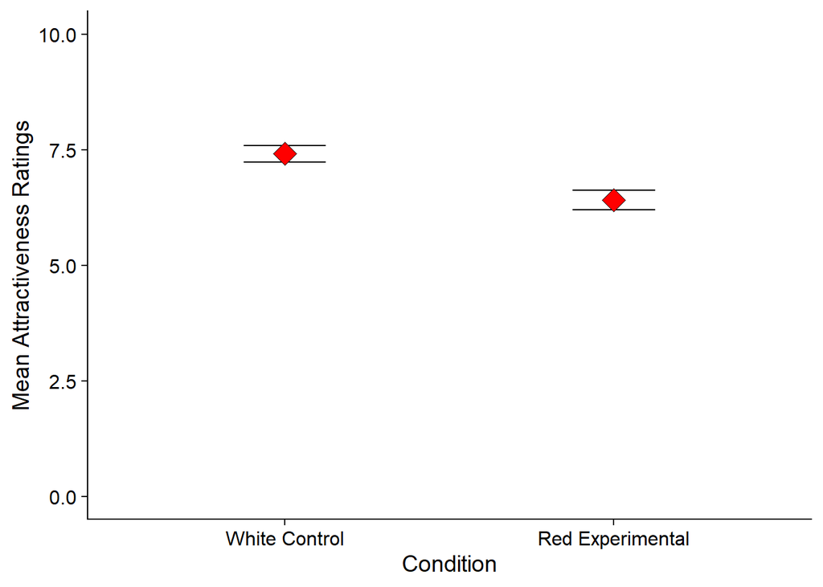

# Discussion

Results for this replication study found that the white control condition had higher mean attractiveness ratings compared to the red experimental condition. Calculated standard deviation was also found to be smaller for the white control condition with minimum and maximum ratings being higher. The statistical *t*-test conducted found that the sample means came from different populations and therefore the condition that participants were in did effect their ratings of attractiveness. This study is a replication of experiment 1 in a 2010 paper written by Elliot et al, which demonstrated through a series of 7 experiments that women perceive men to be more attractive, due to status perception, when seen in conjunction with a red background and in red clothing (Elliot et al., 2010). Examined in experiment 1 of 7 was the effect of the colours red and white on women’s perceptions of a man’s attractiveness (Elliot et al., 2010). In the original study it was concluded through the use of a *t*-test that the condition which participants were in did effect perceived attractiveness ratings which is consistent with our findings (Elliot et al., 2010). However, when comparing these findings to the original study in more detail, we can see that the original paper found that participants in the red condition rated the men as more attractive, whereas in the current replication study, participants in the white condition rated the men as more attractive (Elliot et al., 2010). In terms of the effect investigated, this shows that despite both papers finding a significant difference in the condition attractiveness ratings, the condition with the higher mean attractiveness rating was inconsistent between the original study and this current replication. Further research conducted in this topic area has highlighted that not all studies come to the same conclusions as the the original Elliot et al. 2010 paper. In a study by Peperkoorn and colleagues it was established that results from their three studies showed that those in red clothing were not deemed more attractive than those in white or black, subsequently also failing to support the red effect found in the original Elliot et al paper (Peperkoorn et al., 2016). This pattern of results is more closesly related to those found in the current replication study, where red was not more strongly associated with attractiveness in comparison to white. However in terms of the effect investigated, Peperkoorn and colleagues found that there was no signficant difference between attractiveness ratings in the different colour contexts, while the current replication clearly highlights an increased attractiveness perception for those associated with the colour white over the colour red. In a further study it was concluded that red again did not have a significant effect on perceived attractiveness or subsequent perceived status (Hesslinger et al., 2015). However, from this research it was established that the attractiveness ratings were in fact influenced by the apparel style, with men wearing formal apparel being rated higher than those in casual apparel (Hesslinger et al., 2015). This pattern of results is similar to the current replication study as both did not find a significant red effect on attractiveness perception, however, Hesslinger and colleagues did find that apparel style influenced attractiveness ratings which suggests that other factors have a stronger influence on this perception other than colour. These studies enforce the possibility that the red effect on perceived attractiveness can be overruled by other factors such as apparel style, and suggests that the original study by Elliot et al. 2010 may lack in reliability and therefore significance as it has reduced generalisability. This is also a major limitation of the current study replication, as the sample size was limited, which resulted in an inability to generlise results as they may not be representative. A further limitation of the current replication study is that the only conditions investigated were red and white frame colours, when there is the possibility that other colours and even other factors may have more of an effect on perceived attractiveness, as suggested by Hesslinger and colleagues (Hesslinger et al., 2015). However, a strength of the current replication study is that it develops the idea of ratings of attractiveness being perceived as higher in the white condition where red is not involved, which contradicts the original Elliot et al. findings and reinforces research disporving the red effect. Based on the analysis conducted as well as the comparison to other research in the same field, it would imply that the red effect is not real or possibly only has limited effect on results, with other factors or colours having a higher influence on perceived attractiveness, such as apparel style and the colour white. Future research in this area should investigate the idea that other factors contribute more to perceived attractiveness than the red effect, allowing recent research in this area to be developed further. Factors such as apparel style and different colour conditions may provide useful insight into this area. A repeat of the current investigation with increased sample size would also allow for generalisability to a wider population and make results more reliable in comparison to the current study. To conclude, the current study results support the influence of colour condition yet challenge the red effect as it was reported by Elliot et al. (2010), instead building on research that other factors have a more significant influence on perceived attraction, such as the colour white.

# References

Elliot, A., Niesta Kayser, D., Greitemeyer, T., Lichtenfeld, S., Gramzow, R., Maier, M., & Liu, H. (2010). Red, rank, and romance in women viewing men. Journal Of Experimental Psychology: General, 139(3), 399-417. https://doi.org/10.1037/a0019689

Hesslinger, V., Goldbach, L., & Carbon, C. (2015). Men in red: A reexamination of the red-attractiveness effect. Psychonomic Bulletin & Review, 22(4), 1142-1148. https://doi.org/10.3758/s13423-015-0866-8

Peperkoorn, L., Roberts, S., & Pollet, T. (2016). Revisiting the Red Effect on Attractiveness and Sexual Receptivity. Evolutionary Psychology, 14(4), 147470491667384. https://doi.org/10.1177/1474704916673841